# Biosav RESULTS

Nilda Molina Chacón

2026-09-21

# EXPLORACIÓN DE BIOSAV RESULTS

En el archivo BIOSAV RESULTS se tienen tres sheet’s. Sheet 1 == Empirical (Methods) Sheet 2 == Empirical (Graphs) Sheet 3 == Empirical (Results) Donde cada hoja de excel tiene 0 si aquel método estadístico NO fue implementado por los autores (métodos y/o resultados) y un 1 si es que SÍ fue implementado AL MENOS UNA VEZ. Para los gráficos, es lo mismo, solo que esta vez estaremos viendo si es que existe una relación evidente con los tipos de gráficos v/s los métodos mencionados.

## 1. ANÁLISIS DE RESULTS (SHEET = 1)

### Preparamos los datos para que el software pueda leerlos

Como los archivos excel en español tienen separación distinta entre casillas (;), configuramos todo para que la función read nos permita explorar el contenido. Luego, guardamos los datos como un data.frame clásico, creamos las categorías de los métodos (familias) para una visualización más específica.

```r
library(dplyr)
library(tidyr)
library(ggplot2)
library(readxl)
library(viridis)

cat("=== SELECCIONAR BIOSAV RESULTS (EXCEL) ===\n")
```

```
## === SELECCIONAR BIOSAV RESULTS (EXCEL) ===
```

```r
ruta_archivo <- file.choose()

if (grepl("\\.xlsx?$", ruta_archivo)) {
  df <- read_excel(ruta_archivo, sheet = 1)
} else {
  df <- read.csv(ruta_archivo, sep = ";", check.names = FALSE, fileEncoding = "UTF-8")
}

df <- as.data.frame(df)
rownames(df) <- df[[1]]
df <- df[, -1]

df_num <- df %>%
  mutate(across(everything(), ~ suppressWarnings(as.numeric(as.character(.))))) %>%
  replace(is.na(.), 0)

# Ahora creamos las categorías por familias.
# Cada fila de métodos corresponde a las filas de las familias respectivamente.

categorias <- data.frame(
  Metodo = c(
    'ANOVA', 'T STUDENT', 'KRUSKALL WALLIS', 'MANN WHITNEY', 'WILCOXON', 'CHI SQUARED TEST',
    'PERMANOVA', 'ANOSIM', 'BETADISPER', 'MANTEL TEST',
    'TUKEY', 'LSD TEST', 'BH',
    'PCA', 'PCoA', 'NMDS', 'RDA',
    'SHAPIRO WILK', 'LILLIEFORS', 'LEVENE',
    'PEARSON', 'SPEARMAN', 'SNA',
    'SHANNON', 'INVSIMPSON', 'SIMPSON',
    'GLMM', 'MODELOS BAYESIANOS', 'GWAS', 'WALD TEST',
    'QIIME', 'DADA2', 'PIPELINE', 'Z SCORE',
    'DESEQ2', 'LefSE', 'ANCOM BC'
  ),
  Familia = c(
    rep('1. Diferencias Univariadas', 6),
    rep('2. Hipótesis Multivariada', 4),
    rep('3. Pruebas Post-hoc', 3),
    rep('4. Análisis Multivariado', 4),
    rep('5. Verificación de supuestos', 3),
    rep('6. Relaciones, correlaciones y redes', 3),
    rep('7. Índices Biodiversidad', 3),
    rep('8. Modelamiento Y Genética', 4),
    rep('9. Herramientas Y Preparación', 4),
    rep('10. Abundancia Diferencial', 3)
  )
)
```

### Preparamos los datos para poder graficar

#### 1. El gráfico 1:

Será un gráfico exploratorio para saber las frecuencias de métodos estadísticos. Mostrará de manera descendiente desde cuáles son los más comunes hasta los menos utilizados en estos 49 papers seleccionados.

#### 2. El gráfico 2:

Este gráfico ahora relacionrá las frecuencias con las familias de métodos estadísticos. Es decir, la idea es que para cada barra según la columna de métodos, esta se coloree según la familia o categoría de los métodos.

#### 3. El gráfico 3:

Es la misma ciencia que el gráfico 3, solo que ahora colorearemos únicamente el top 3 de las familias de métodos estadísticos más usados.

#### 4. El gráfico 4:

Para este gráfico contaremos en cuántos papers se utilizó AL MENOS uno de los métodos estadísticos de la familia. De esta manera contamos únicamente las familias, evitando repeticiones.

```r
frecuencias_plot <- data.frame(
  Metodo = colnames(df_num),
  Frecuencia = colSums(df_num, na.rm = TRUE)
) %>%
  filter(Metodo != "Publication Year") %>%
  filter(Frecuencia > 0) %>%
  left_join(categorias, by = "Metodo") %>%
  mutate(Familia = replace_na(Familia, "Otros"))

top_familias <- frecuencias_plot %>%
  group_by(Familia) %>%
  summarise(Suma_Total = sum(Frecuencia)) %>%
  arrange(desc(Suma_Total)) %>%
  slice(1:3) %>%
  pull(Familia)

frecuencias_plot <- frecuencias_plot %>%
  mutate(Familia_Top3 = if_else(Familia %in% top_familias, Familia, "Otras Familias")) %>%
  arrange(Frecuencia) %>%
  mutate(Metodo = factor(Metodo, levels = Metodo)) %>%
  mutate(Familia_Top3 = factor(Familia_Top3, levels = c(top_familias, "Otras Familias")))

frecuencia_familias <- df_num %>%
  mutate(Paper_ID = rownames(.)) %>%
  pivot_longer(cols = -Paper_ID, names_to = "Metodo", values_to = "Presencia") %>%
  filter(Metodo != "Publication Year", Presencia > 0) %>%
  left_join(categorias, by = "Metodo") %>%
  mutate(Familia = replace_na(Familia, "Otros")) %>%
  distinct(Paper_ID, Familia) %>%
  count(Familia, name = "Frecuencia") %>%
  arrange(Frecuencia) %>%
  mutate(Familia = factor(Familia, levels = Familia))
```

### Generamos gráficos

Finalmente, creamos las visualizaciones

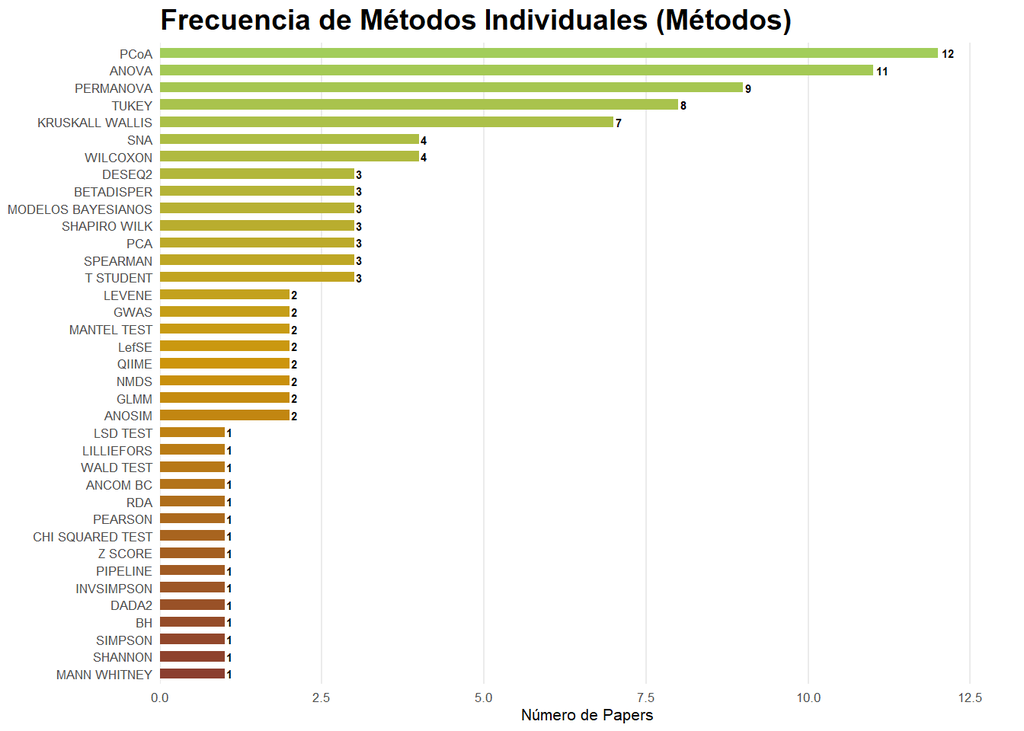

```r
# Gráfico 1: Exploratorio
mis_colores_degradado <- colorRampPalette(c("coral4", "darkgoldenrod3", "darkolivegreen3"))(nrow(frecuencias_plot))

ggplot(frecuencias_plot, aes(x = Frecuencia, y = Metodo, fill = Metodo)) +
  geom_col(width = 0.6, show.legend = FALSE) +
  geom_text(aes(label = Frecuencia), hjust = -0.3, size = 2, fontface = "bold") +
  scale_fill_manual(values = mis_colores_degradado) +
  labs(title = "Frecuencia de Métodos Individuales (Métodos)", x = "Número de Papers", y = NULL) +
  theme_minimal(base_size = 8) +
  theme(
    plot.title = element_text(face = "bold", size = 14),
    plot.subtitle = element_text(color = "gray40", margin = margin(b = 10)),
    panel.grid.major.y = element_blank(),
    panel.grid.minor = element_blank()
  ) +
  scale_x_continuous(expand = expansion(mult = c(0, 0.1)))
```

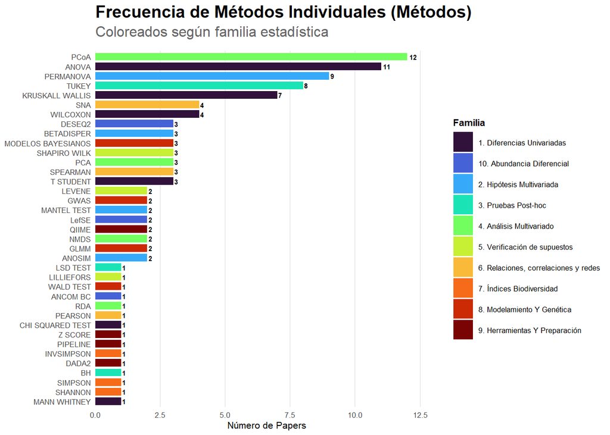

```r
# Gráfico 2: Por Familias de métodos
ggplot(frecuencias_plot, aes(x = Frecuencia, y = Metodo, fill = Familia)) +
  geom_col(width = 0.8) +
  geom_text(aes(label = Frecuencia), hjust = -0.3, size = 2, fontface = "bold", color = "black") +
  scale_fill_viridis_d(option = "turbo") +
  labs(title = "Frecuencia de Métodos Individuales (Métodos)", subtitle = "Coloreados según familia estadística", x = "Número de Papers", y = NULL) +
  theme_minimal(base_size = 8) +
  theme(
    plot.title = element_text(face = "bold", size = 14),
    plot.subtitle = element_text(size = 12, color = "gray40", margin = margin(b = 10)),
    legend.position = "right",
    legend.title = element_text(face = "bold"),
    panel.grid.major.y = element_blank(), # Quitamos líneas de fondo horizontales
    panel.grid.minor = element_blank()
  ) +
  scale_x_continuous(expand = expansion(mult = c(0, 0.1)))
```

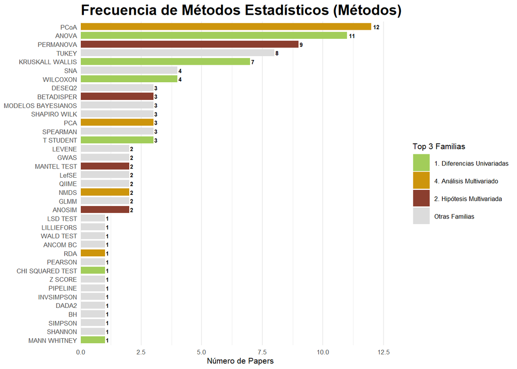

```r
# Gráfico 3: Top 3 Familias de métodos
mis_colores <- c("darkolivegreen3", "darkgoldenrod3", "coral4", "gainsboro")
names(mis_colores) <- c(top_familias, "Otras Familias")

ggplot(frecuencias_plot, aes(x = Frecuencia, y = Metodo, fill = Familia_Top3)) +
  geom_col(width = 0.8) +
  geom_text(aes(label = Frecuencia), hjust = -0.3, size = 2, fontface = "bold") +
  scale_fill_manual(values = mis_colores) +
  labs(title = "Frecuencia de Métodos Estadísticos (Métodos)", x = "Número de Papers", y = NULL, fill = "Top 3 Familias") +
  theme_minimal(base_size = 8) +
  theme(
    plot.title = element_text(face = "bold", size = 14),
    plot.subtitle = element_text(color = "gray40", margin = margin(b = 10)),
    panel.grid.major.y = element_blank()
  ) +
  scale_x_continuous(expand = expansion(mult = c(0, 0.1)))
```

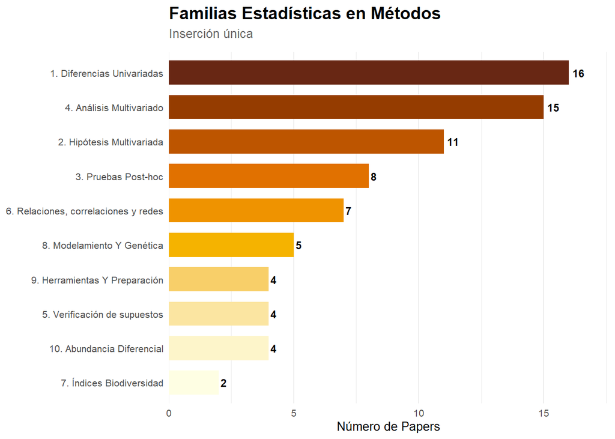

```r
# Gráfico 4: ÚNICAMENTE por Familias
ggplot(frecuencia_familias, aes(x = Frecuencia, y = Familia, fill = Familia)) +
  geom_col(width = 0.7, show.legend = FALSE) +
  geom_text(aes(label = Frecuencia), hjust = -0.3, size = 3, fontface = "bold") +
  scale_fill_manual(values = hcl.colors(n = nrow(frecuencia_familias), palette = "YlOrBr", rev = TRUE)) +
  labs(title = "Familias Estadísticas en Métodos", subtitle = "Inserción única", x = "Número de Papers", y = NULL) +
  theme_minimal(base_size = 10) +
  theme(
    plot.title = element_text(face = "bold", size = 14),
    plot.subtitle = element_text(color = "gray40", margin = margin(b = 10)),
    panel.grid.major.y = element_blank()
  ) +
  scale_x_continuous(expand = expansion(mult = c(0, 0.1)))
```

## 2. ANÁLISIS DE RESULTS (SHEET = 3)

### Preparamos los datos para los resultados

Ahora la idea es que se lea únicamente la hoja n°3, donde nuevamente indicamos todo lo necesario y creamos el data.frame clásico. Además, también creamos familias de métodos estadísticos, similar a lo que se hizo anteriormente para lo observado en la sección de métodos.

La idea aquí también es obtener los mismos gráficos que en la sheet 1; es decir:

#### 1. El gráfico 1:

Será un gráfico exploratorio para saber las frecuencias de métodos estadísticos esta vez en los resultados. Mostrará de manera descendiente desde cuáles son los más comunes hasta los menos utilizados en estos 49 papers seleccionados.

#### 2. El gráfico 2:

Este gráfico ahora relacionrá las frecuencias con las familias de métodos estadísticos. Es decir, la idea es que para cada barra según la columna de métodos, esta se coloree según la familia o categoría de los métodos.

#### 3. El gráfico 3:

Es la misma ciencia que el gráfico 3, solo que ahora colorearemos únicamente el top 3 de las familias de métodos estadísticos más usados.

#### 4. El gráfico 4:

Para este gráfico contaremos en cuántos papers se utilizó AL MENOS uno de los métodos estadísticos de la familia. De esta manera contamos únicamente las familias, evitando repeticiones.

```r
if (grepl("\\.xlsx?$", ruta_archivo)) {
  df_res <- read_excel(ruta_archivo, sheet = 3)
} else {
  df_res <- read.csv(ruta_archivo, sep = ";", check.names = FALSE, fileEncoding = "UTF-8")
}

df_res <- as.data.frame(df_res)
rownames(df_res) <- df_res[[1]]
df_res <- df_res[, -1]

df_num_res <- df_res %>%
  mutate(across(everything(), ~ suppressWarnings(as.numeric(as.character(.))))) %>%
  replace(is.na(.), 0)

categorias_res <- data.frame(
  Metodo = c(
    'ANOVA', 'KRUSKALL WALLIS', 'WILCOXON', 'T STUDENT', 'CHI SQUARED', 'MANN WHITNEY',
    'PERMANOVA', 'BETADISPER', 'ANOSIM', 'MANTEL TEST',
    'TUKEY', 'FDR', 'DUNN', 'LSD TEST', 'HOLM SIDAK',
    'PCoA', 'NMDS', 'PCA', 'RDA',
    'SNA', 'SPEARMAN', 'PEARSON',
    'ENS',
    'MODELOS BAYESIANOS', 'RMSE', 'AIC', 'K FOLD', 'LIKELIHOOD TEST', 'WALD TEST', 'GWAS', 'PAV', 'GLMM',
    'BLAST N', 'RMT', 'Sloan NCM', 'QIIME',
    'ANCOM BC', 'LefSE'
  ),
  Familia = c(
    rep('1. Diferencias Univariadas', 6),
    rep('2. Hipótesis Multivariada', 4),
    rep('3. Pruebas Post-hoc', 5),
    rep('4. Análisis Multivariado', 4),
    rep('6. Relaciones, correlaciones y redes', 3),
    rep('7. Índices Biodiversidad', 1),
    rep('8. Modelamiento Y Genética', 9),
    rep('9. Herramientas Y Preparación', 4),
    rep('10. Abundancia Diferencial', 2)
  )
)

frecuencias_plot_res <- data.frame(
  Metodo = colnames(df_num_res),
  Frecuencia = colSums(df_num_res, na.rm = TRUE)
) %>%
  filter(Frecuencia > 0) %>%
  left_join(categorias_res, by = "Metodo") %>%
  mutate(Familia = replace_na(Familia, "Otros"))

top_familias_res <- frecuencias_plot_res %>%
  group_by(Familia) %>%
  summarise(Suma_Total = sum(Frecuencia)) %>%
  arrange(desc(Suma_Total)) %>%
  slice(1:3) %>%
  pull(Familia)

frecuencias_plot_res <- frecuencias_plot_res %>%
  mutate(Familia_Top3 = if_else(Familia %in% top_familias_res, Familia, "Otras Familias")) %>%
  arrange(Frecuencia) %>%
  mutate(Metodo = factor(Metodo, levels = Metodo)) %>%
  mutate(Familia_Top3 = factor(Familia_Top3, levels = c(top_familias_res, "Otras Familias")))

frecuencia_familias_res <- df_num_res %>%
  mutate(Paper_ID = rownames(.)) %>%
  pivot_longer(cols = -Paper_ID, names_to = "Metodo", values_to = "Presencia") %>%
  filter(Presencia > 0) %>%
  left_join(categorias_res, by = "Metodo") %>%
  mutate(Familia = replace_na(Familia, "Otros")) %>%
  distinct(Paper_ID, Familia) %>%
  count(Familia, name = "Frecuencia") %>%
  arrange(Frecuencia) %>%
  mutate(Familia = factor(Familia, levels = Familia))
```

### Graficamos ahora los resultados

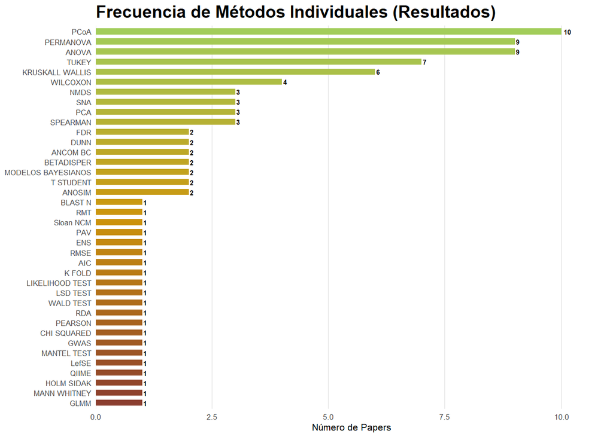

```r
# Grafico 1: Exploratorio por frecuencias
mis_colores_degradado_res <- colorRampPalette(c("coral4", "darkgoldenrod3", "darkolivegreen3"))(nrow(frecuencias_plot_res))

ggplot(frecuencias_plot_res, aes(x = Frecuencia, y = Metodo, fill = Metodo)) +
  geom_col(width = 0.6, show.legend = FALSE) +
  geom_text(aes(label = Frecuencia), hjust = -0.3, size = 2, fontface = "bold") +
  scale_fill_manual(values = mis_colores_degradado_res) +
  labs(title = "Frecuencia de Métodos Individuales (Resultados)", x = "Número de Papers", y = NULL) +
  theme_minimal(base_size = 8) +
  theme(
    plot.title = element_text(face = "bold", size = 14),
    plot.subtitle = element_text(color = "gray40", margin = margin(b = 10)),
    panel.grid.major.y = element_blank(),
    panel.grid.minor = element_blank()
  ) +
  scale_x_continuous(expand = expansion(mult = c(0, 0.1)))
```

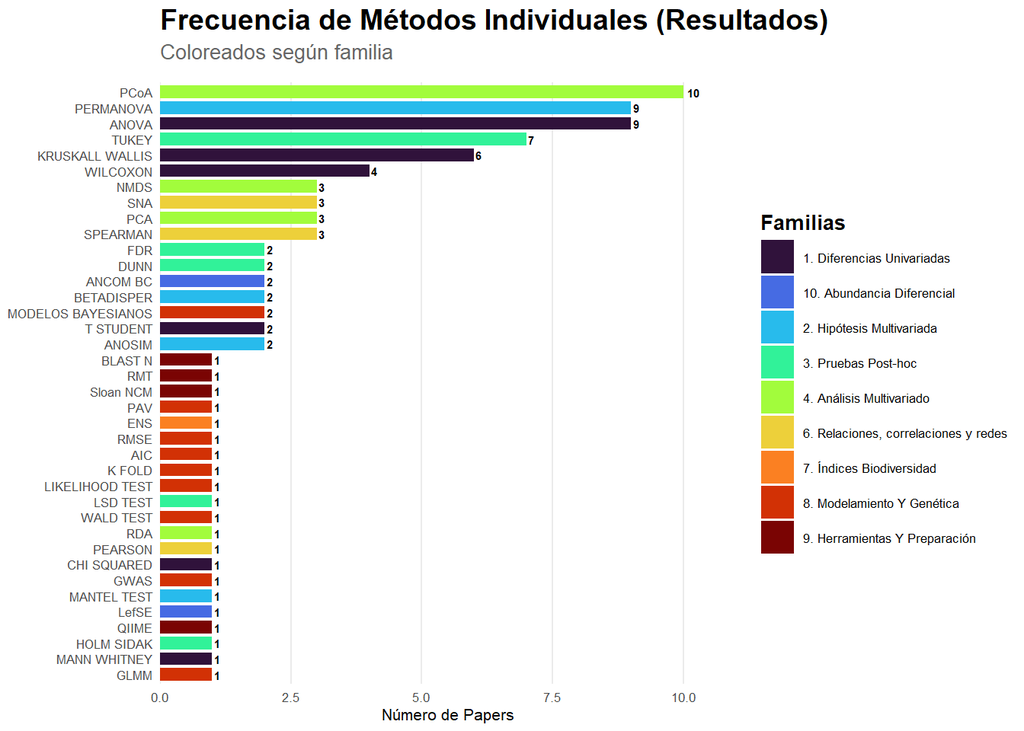

```r
# Gráfico 2: Por Familias de métodos
ggplot(frecuencias_plot_res, aes(x = Frecuencia, y = Metodo, fill = Familia)) +
  geom_col(width = 0.8) +
  geom_text(aes(label = Frecuencia), hjust = -0.3, size = 2, fontface = "bold", color = "black") +
  scale_fill_viridis_d(option = "turbo") +
  labs(title = "Frecuencia de Métodos Individuales (Resultados)", subtitle = "Coloreados según familia", x = "Número de Papers", y = NULL, fill = "Familias") +
  theme_minimal(base_size = 8) +
  theme(
    plot.title = element_text(face = "bold", size = 14),
    plot.subtitle = element_text(size = 10, color = "gray40", margin = margin(b = 10)),
    legend.position = "right",
    legend.title = element_text(face = "bold", size = 10),
    panel.grid.major.y = element_blank(),
    panel.grid.minor = element_blank()
  ) +
  scale_x_continuous(expand = expansion(mult = c(0, 0.1)))
```

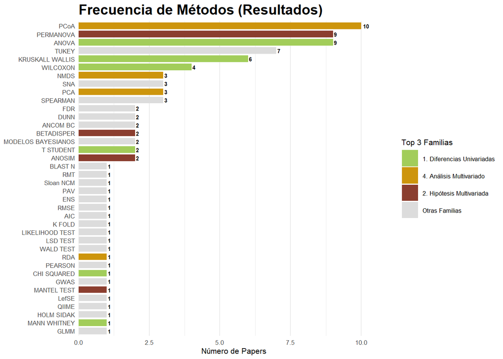

```r
# Gráfico 3: Top 3 Familias
mis_colores_res <- c("darkolivegreen3", "darkgoldenrod3", "coral4", "gainsboro")
names(mis_colores_res) <- c(top_familias_res, "Otras Familias")

ggplot(frecuencias_plot_res, aes(x = Frecuencia, y = Metodo, fill = Familia_Top3)) +
  geom_col(width = 0.8) +
  geom_text(aes(label = Frecuencia), hjust = -0.3, size = 2, fontface = "bold") +
  scale_fill_manual(values = mis_colores_res) +
  labs(title = "Frecuencia de Métodos (Resultados)", x = "Número de Papers", y = NULL, fill = "Top 3 Familias") +
  theme_minimal(base_size = 8) +
  theme(
    plot.title = element_text(face = "bold", size = 14),
    plot.subtitle = element_text(color = "gray40", margin = margin(b = 10)),
    panel.grid.major.y = element_blank()
  ) +
  scale_x_continuous(expand = expansion(mult = c(0, 0.1)))
```

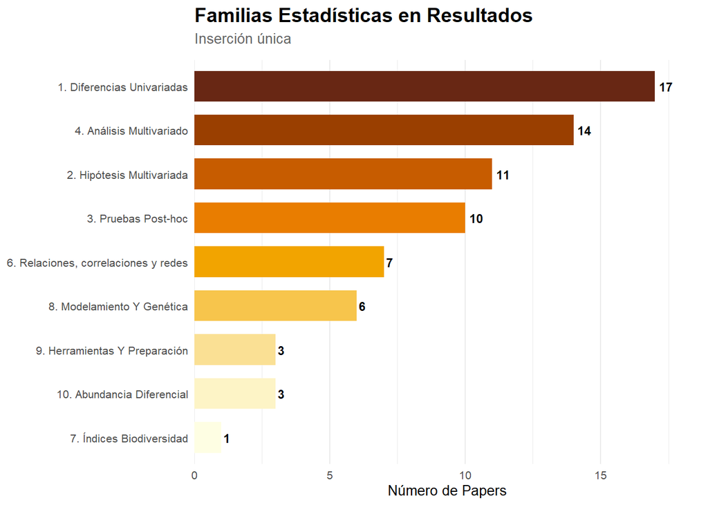

```r
# 4. Gráfico 4: Solo Familias
ggplot(frecuencia_familias_res, aes(x = Frecuencia, y = Familia, fill = Familia)) +
  geom_col(width = 0.7, show.legend = FALSE) +
  geom_text(aes(label = Frecuencia), hjust = -0.3, size = 3, fontface = "bold") +
  scale_fill_manual(values = hcl.colors(n = nrow(frecuencia_familias_res), palette = "YlOrBr", rev = TRUE)) +
  labs(title = "Familias Estadísticas en Resultados", subtitle = "Inserción única", x = "Número de Papers", y = NULL) +
  theme_minimal(base_size = 10) +
  theme(
    plot.title = element_text(face = "bold", size = 14),
    plot.subtitle = element_text(color = "gray40", margin = margin(b = 10)),
    panel.grid.major.y = element_blank()
  ) +
  scale_x_continuous(expand = expansion(mult = c(0, 0.1)))
```

## 3. ANÁLISIS DE GRÁFICOS (SHEET = 2)

En esta sección exploraremos los tipos de gráficos utilizados por los autores para reportar sus observaciones, extrayendo la información de la segunda hoja del documento excel.

### Preparación y cálculos

Ahora, nuevamente preparamos el excel, lo convertimos en data.frame y definimos las familias de los gáficos para visualizar las preferencias de la literatura. Luego, hacemos los cálculos y definiciones necesarias para poder tener nuevamente los 4 gráficos pero para la sección de gráficos dentro de los papers.

#### 1. El gráfico 1:

Será un gráfico exploratorio para saber las frecuencias de los tipos de gráficos usados por los autores.

#### 2. El gráfico 2:

Este gráfico ahora relacionrá las frecuencias con las familias de los gráficos.

#### 3. El gráfico 3:

Es la misma ciencia que el gráfico 3, solo que ahora colorearemos únicamente el top 3.

#### 4. El gráfico 4:

Para este gráfico contaremos en cuántos papers se utilizó AL MENOS uno de los gráficos clasificados en las familias.

```r
if (grepl("\\.xlsx?$", ruta_archivo)) {
  df_graficos <- read_excel(ruta_archivo, sheet = 2)
} else {
  df_graficos <- read.csv(ruta_archivo, sep = ";", check.names = FALSE, fileEncoding = "UTF-8")
}

df_graficos <- as.data.frame(df_graficos)
rownames(df_graficos) <- df_graficos[[1]]
df_graficos <- df_graficos[, -1]

df_num_graficos <- df_graficos %>%
  mutate(across(everything(), ~ suppressWarnings(as.numeric(as.character(.))))) %>%
  replace(is.na(.), 0)

# Definimos las familias de gráficos
categorias_graficos <- data.frame(
  Tipo_Grafico = c(
    'BOXPLOT', 'SIDE-BY-SIDE BOXPLOT', 'VIOLIN PLOT', 'DENSITY PLOT', 'HISTOGRAM', 'STRIP PLOT', 'JITTER PLOT',
    'BAR CHART WITH ERROR', 'BAR CHART SIMPLE', 'LINE CHART', 'LINE CHART WITH ERROR', 'SCATTER PLOT SIMPLE', 'REGRESSION PLOT', 'CLEVELAND DOT POINT',
    'PCOA SCATTERPLOT', 'PCA SCATTERPLOT', 'NMDS PLOT', 'db-RDA',
    'STACKED BAR CHART', 'SANKEY PLOT', 'PIE CHART', 'BUBBLE CHART',
    'HEATMAP', 'CLUSTERED HEATMAP', 'DENDROGRAM', 'CIRCULAR DENDROGRAM', 'MAXIMUM LIKELIHOOD TREES',
    'CO-OCCURRENCE NETWORK', 'ZIPI PLOT', 'VENN DIAGRAM', 'UPSET PLOT',
    'LDA SCORE PLOT', 'MANHATTAN PLOT', 'MA PLOT', 'VOLCANO PLOT'
  ),
  Familia = c(
    rep('1. Distribución y Dispersión', 7),
    rep('2. Comparaciones y Tendencias', 7),
    rep('3. Ordenación Multivariada', 4),
    rep('4. Composición Comunitaria', 4),
    rep('5. Agrupamiento y Redes', 9),
    rep('6. Biomarcadores y Genómica', 4)
  )
)

#  Cálculos de frecuencias base y unión con familias
frecuencias_plot_graficos <- data.frame(
  Tipo_Grafico = colnames(df_num_graficos),
  Frecuencia = colSums(df_num_graficos, na.rm = TRUE)
) %>%
  filter(Tipo_Grafico != "Publication Year", Frecuencia > 0) %>%
  left_join(categorias_graficos, by = "Tipo_Grafico") %>%
  mutate(Familia = replace_na(Familia, "Otros"))

# Cálculo del Top 3 familias
top_familias_graf <- frecuencias_plot_graficos %>%
  group_by(Familia) %>%
  summarise(Suma_Total = sum(Frecuencia)) %>%
  arrange(desc(Suma_Total)) %>%
  slice(1:3) %>%
  pull(Familia)

frecuencias_plot_graficos <- frecuencias_plot_graficos %>%
  mutate(Familia_Top3 = if_else(Familia %in% top_familias_graf, Familia, "Otras Familias")) %>%
  arrange(Frecuencia) %>%
  mutate(Tipo_Grafico = factor(Tipo_Grafico, levels = Tipo_Grafico)) %>%
  mutate(Familia_Top3 = factor(Familia_Top3, levels = c(top_familias_graf, "Otras Familias")))

# Cálculo para gráfico por familia
frecuencia_familias_graf <- df_num_graficos %>%
  mutate(Paper_ID = rownames(.)) %>%
  pivot_longer(cols = -Paper_ID, names_to = "Tipo_Grafico", values_to = "Presencia") %>%
  filter(Tipo_Grafico != "Publication Year", Presencia > 0) %>%
  left_join(categorias_graficos, by = "Tipo_Grafico") %>%
  mutate(Familia = replace_na(Familia, "Otros")) %>%
  distinct(Paper_ID, Familia) %>%
  count(Familia, name = "Frecuencia") %>%
  arrange(Frecuencia) %>%
  mutate(Familia = factor(Familia, levels = Familia))
```

#### Visualizaciones

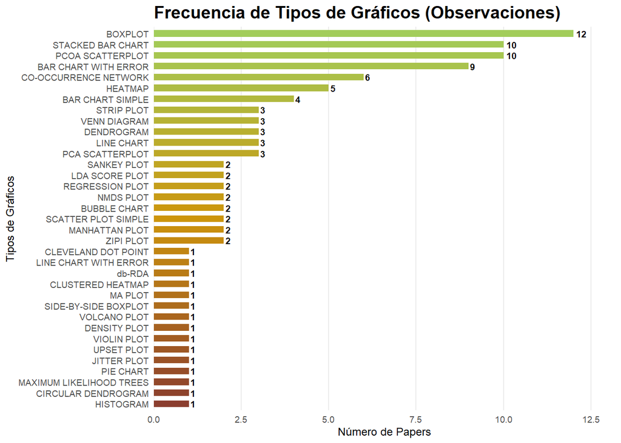

```r
# 1. Gráfico 1: Frecuencias por tipo de gráfico
mis_colores_graficos <- colorRampPalette(c("coral4", "darkgoldenrod3", "darkolivegreen3"))(nrow(frecuencias_plot_graficos))

ggplot(frecuencias_plot_graficos, aes(x = Frecuencia, y = Tipo_Grafico, fill = Tipo_Grafico)) +
  geom_col(width = 0.6, show.legend = FALSE) +
  geom_text(aes(label = Frecuencia), hjust = -0.3, size = 2.5, fontface = "bold") +
  scale_fill_manual(values = mis_colores_graficos) +
  labs(title = "Frecuencia de Tipos de Gráficos (Observaciones)", x = "Número de Papers", y = "Tipos de Gráficos") +
  theme_minimal(base_size = 9) +
  theme(plot.title = element_text(face = "bold", size = 14), plot.subtitle = element_text(color = "gray40", margin = margin(b = 10)), panel.grid.major.y = element_blank(), panel.grid.minor = element_blank()) +
  scale_x_continuous(expand = expansion(mult = c(0, 0.1)))
```

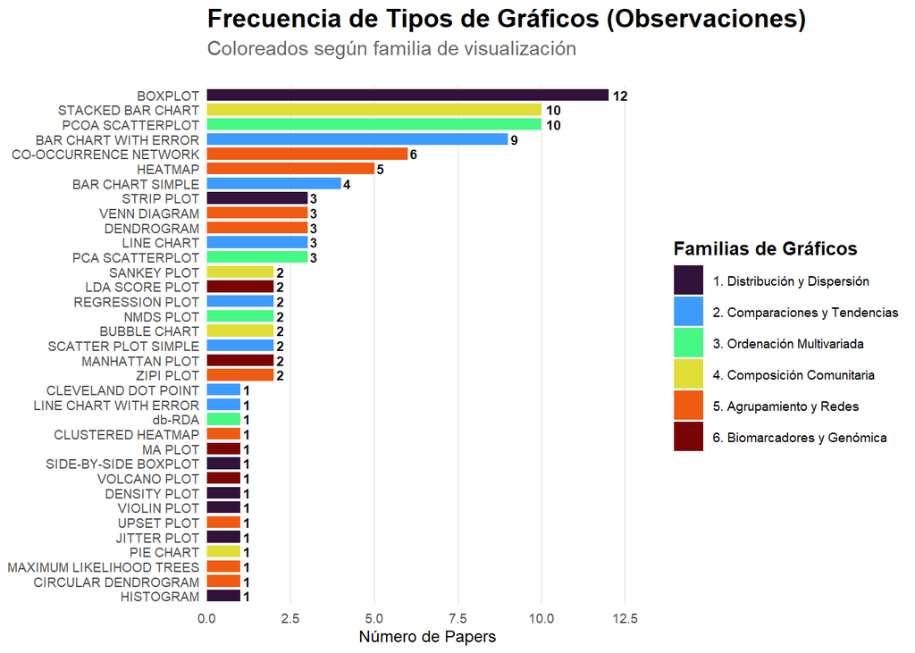

```r
# 1.1. Gráfico 1.1: Frecuencias por tipo de gráfico TRUNCADO AL TOP 3


# 2. Gráfico 2: Frecuencias coloreados por Familia
ggplot(frecuencias_plot_graficos, aes(x = Frecuencia, y = Tipo_Grafico, fill = Familia)) +
  geom_col(width = 0.8) +
  geom_text(aes(label = Frecuencia), hjust = -0.3, size = 2.5, fontface = "bold", color = "black") +
  scale_fill_viridis_d(option = "turbo") +
  labs(title = "Frecuencia de Tipos de Gráficos (Observaciones)", subtitle = "Coloreados según familia de visualización", x = "Número de Papers", y = NULL, fill = "Familias de Gráficos") +
  theme_minimal(base_size = 9) +
  theme(plot.title = element_text(face = "bold", size = 14), plot.subtitle = element_text(size = 11, color = "gray40", margin = margin(b = 15)), legend.position = "right", legend.title = element_text(face = "bold", size = 10), panel.grid.major.y = element_blank(), panel.grid.minor = element_blank()) +
  scale_x_continuous(expand = expansion(mult = c(0, 0.1)))
```

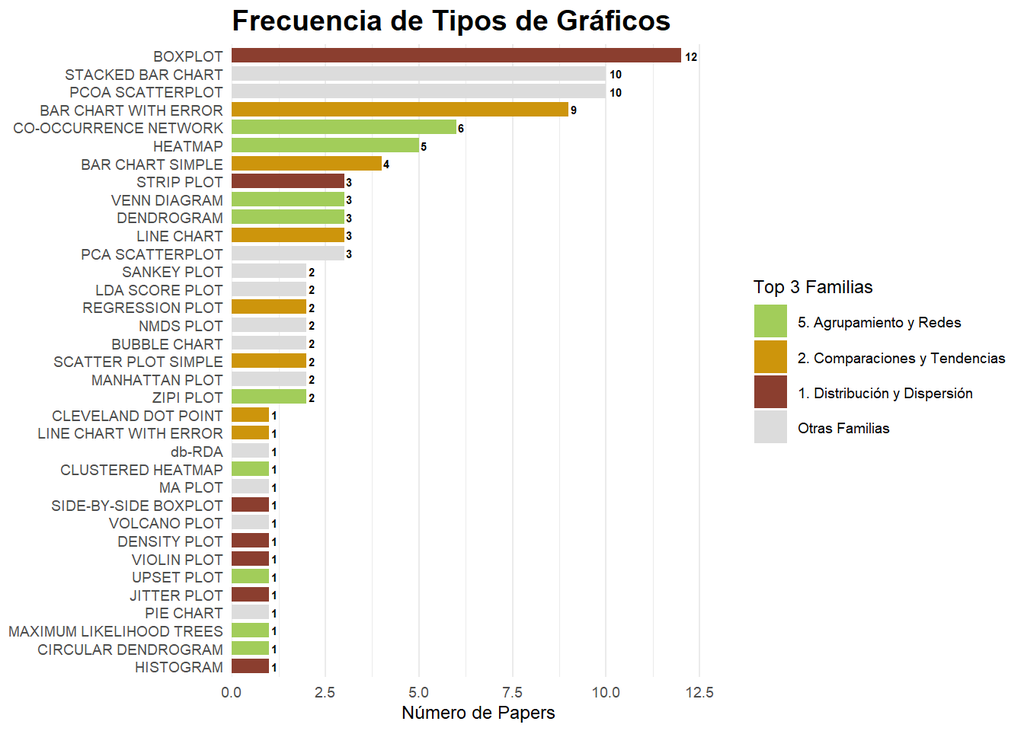

```r
# 3. Gráfico 3: Top 3 Familias de gráficos
mis_colores_graf <- c("darkolivegreen3", "darkgoldenrod3", "coral4", "gainsboro")
names(mis_colores_graf) <- c(top_familias_graf, "Otras Familias")

ggplot(frecuencias_plot_graficos, aes(x = Frecuencia, y = Tipo_Grafico, fill = Familia_Top3)) +
  geom_col(width = 0.8) +
  geom_text(aes(label = Frecuencia), hjust = -0.3, size = 2, fontface = "bold") +
  scale_fill_manual(values = mis_colores_graf) +
  labs(title = "Frecuencia de Tipos de Gráficos", x = "Número de Papers", y = NULL, fill = "Top 3 Familias") +
  theme_minimal(base_size = 9) +
  theme(plot.title = element_text(face = "bold", size = 14), plot.subtitle = element_text(color = "gray40", margin = margin(b = 10)), panel.grid.major.y = element_blank()) +
  scale_x_continuous(expand = expansion(mult = c(0, 0.1)))
```

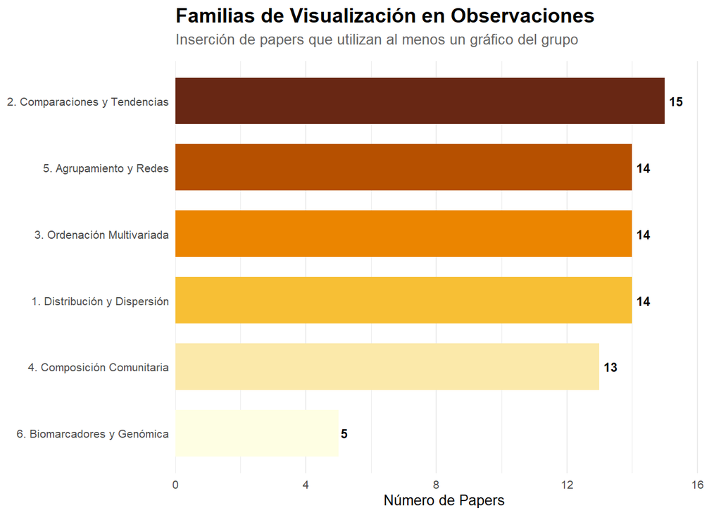

```r
# 4. Gráfico 4: Solo Familias
ggplot(frecuencia_familias_graf, aes(x = Frecuencia, y = Familia, fill = Familia)) +
  geom_col(width = 0.7, show.legend = FALSE) +
  geom_text(aes(label = Frecuencia), hjust = -0.3, size = 3, fontface = "bold") +
  scale_fill_manual(values = hcl.colors(n = nrow(frecuencia_familias_graf), palette = "YlOrBr", rev = TRUE)) +
  labs(title = "Familias de Visualización en Observaciones", subtitle = "Inserción de papers que utilizan al menos un gráfico del grupo", x = "Número de Papers", y = NULL) +
  theme_minimal(base_size = 10) +
  theme(plot.title = element_text(face = "bold", size = 14), plot.subtitle = element_text(color = "gray40", margin = margin(b = 10)), panel.grid.major.y = element_blank()) +
  scale_x_continuous(expand = expansion(mult = c(0, 0.1)))
```

# Análisis MCA

Este es solo un análisis MCA para la SHEET=1

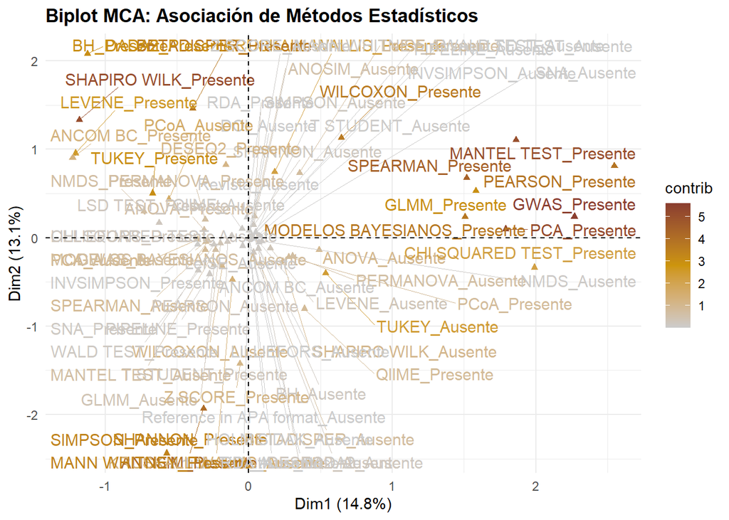

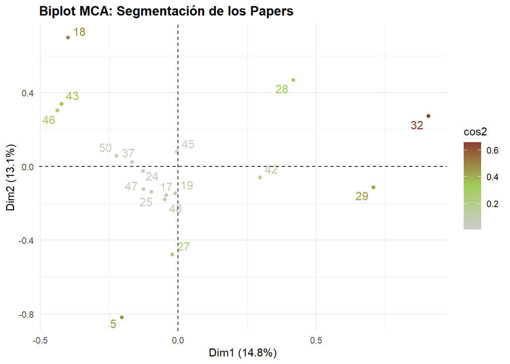

```r
library(FactoMineR)
library(factoextra)

# Preparación de datos: Convertir la matriz binaria a factores
df_mca_metodos <- df_num %>%
  mutate(across(everything(), ~ as.factor(ifelse(. == 1, "Presente", "Ausente"))))

# Ejecutamos el cálculo del MCA
modelo_mca <- MCA(df_mca_metodos, graph = FALSE)

# 1. Visualización 1: El mapa de las variables (Métodos Estadísticos)
# Muestra qué métodos tienden a usarse juntos (clústeres analíticos)
plot_metodos_mca <- fviz_mca_var(modelo_mca,
                                 choice = "var.cat",
                                 repel = TRUE, # Evita que los textos se sobrepongan
                                 col.var = "contrib", # Coloreamos según peso
                                 gradient.cols = c("gray80", "darkgoldenrod3", "coral4"),
                                 title = "Biplot MCA: Asociación de Métodos Estadísticos") +
  theme_minimal(base_size = 11) +
  theme(plot.title = element_text(face = "bold"))

print(plot_metodos_mca)

# 2. Visualización 2: El mapa de los individuos (Los 49 Papers)
# Muestra si los artículos se dividen en "escuelas" de análisis distintas
plot_papers_mca <- fviz_mca_ind(modelo_mca,
                                repel = TRUE,
                                col.ind = "cos2", # Coloreamos por calidad de representación
                                gradient.cols = c("gray80", "darkolivegreen3", "coral4"),
                                title = "Biplot MCA: Segmentación de los Papers") +
  theme_minimal(base_size = 11) +
  theme(plot.title = element_text(face = "bold"))

print(plot_papers_mca)
```

Ahora un MCA cruzado para la SHEET = 1 y la SHEET = 3

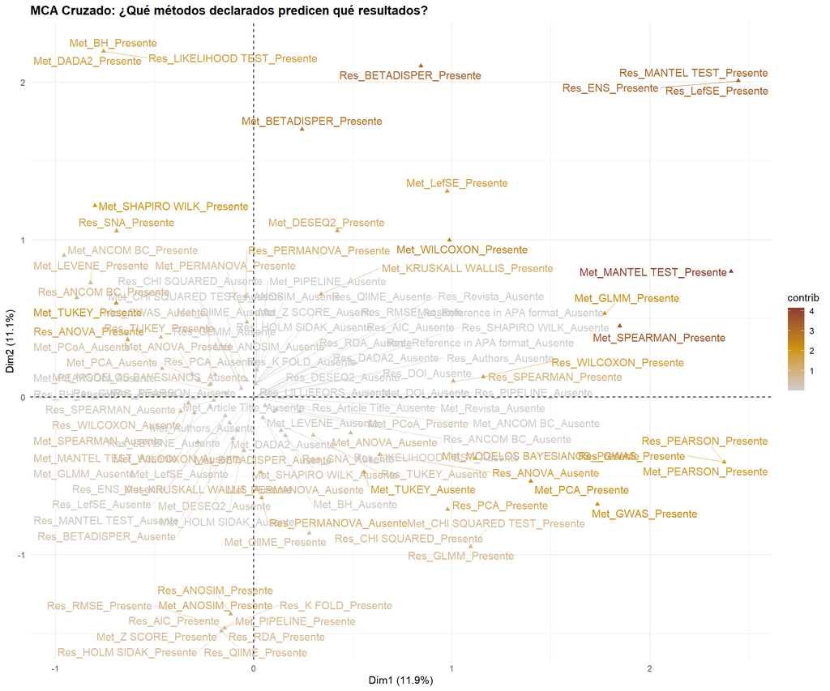

```r
# Cargar librerías necesarias
library(FactoMineR)
library(factoextra)
library(dplyr)
library(tibble)

# Agregamos prefijos para no confundir métodos declarados vs resultados reportados
df_metodos_mca <- df_num %>%
  rename_with(~ paste0("Met_", .)) %>%
  rownames_to_column("Paper_ID")

df_resultados_mca <- df_num_res %>%
  rename_with(~ paste0("Res_", .)) %>%
  rownames_to_column("Paper_ID")

# Matriz cruzada a través de la ID del paper
df_super_matriz <- inner_join(df_metodos_mca, df_resultados_mca, by = "Paper_ID") %>%
  column_to_rownames("Paper_ID")

# Categorizamos los datos
df_super_mca <- df_super_matriz %>%
  mutate(across(everything(), ~ as.factor(ifelse(. == 1, "Presente", "Ausente"))))

# MCA
# Guardamos solo las 5 primeras dimensiones para mayor rapidez
modelo_mca_cruzado <- MCA(df_super_mca, ncp = 5, graph = FALSE)

# Excluimos las etiquetas de "Ausente" para no saturar el gráfico y ver solo lo que SÍ se conectó
plot_mca_cruzado <- fviz_mca_var(modelo_mca_cruzado,
                                 choice = "var.cat",
                                 invisible = "ind", # Oculta los papers
                                 select.var = list(name = NULL, cos2 = 0.1), # Filtramos para no saturar
                                 repel = TRUE,
                                 col.var = "contrib",
                                 gradient.cols = c("gray80", "darkgoldenrod3", "coral4"),
                                 title = "MCA Cruzado: ¿Qué métodos declarados predicen qué resultados?") +
  theme_minimal(base_size = 11) +
  theme(plot.title = element_text(face = "bold"))

print(plot_mca_cruzado)
```

# Top contribuyentes

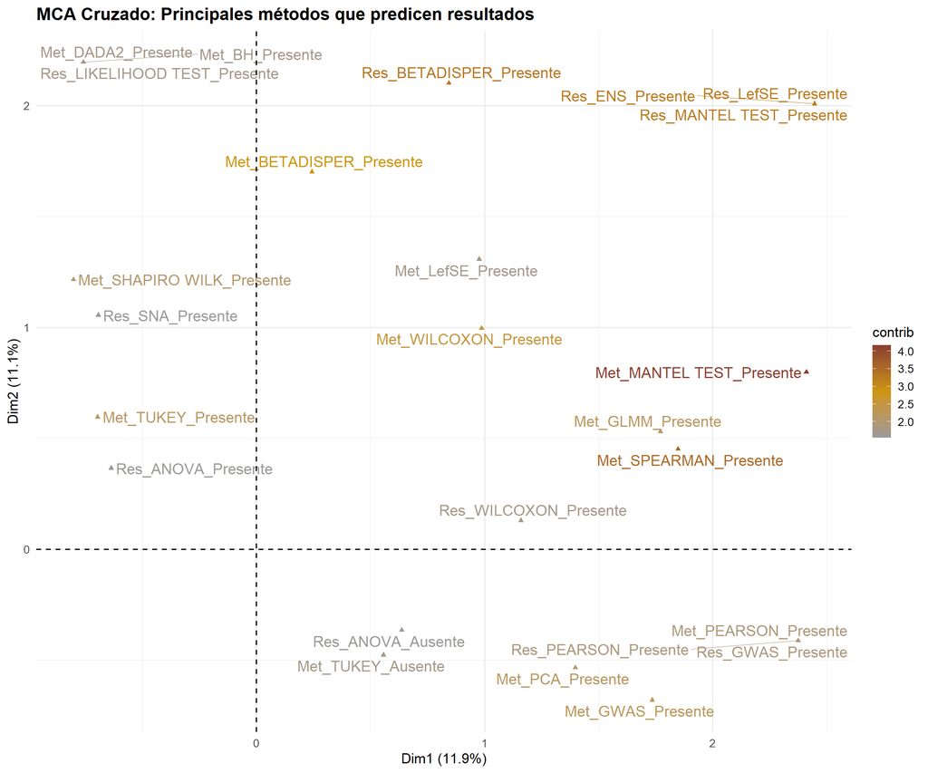

```r
library(FactoMineR)
library(factoextra)
library(dplyr)
library(tibble)

# Agregamos prefijos métodos declarados vs resultados reportados
df_metodos_mca <- df_num %>%
  rename_with(~ paste0("Met_", .)) %>%
  rownames_to_column("Paper_ID")

df_resultados_mca <- df_num_res %>%
  rename_with(~ paste0("Res_", .)) %>%
  rownames_to_column("Paper_ID")

# Matriz cruzada
df_super_matriz <- inner_join(df_metodos_mca, df_resultados_mca, by = "Paper_ID") %>%
  column_to_rownames("Paper_ID")

# Categorizamos los datos
df_super_mca <- df_super_matriz %>%
  mutate(across(everything(), ~ as.factor(ifelse(. == 1, "Presente", "Ausente"))))

# MCA
modelo_mca_cruzado <- MCA(df_super_mca, ncp = 5, graph = FALSE)

plot_mca_cruzado <- fviz_mca_var(modelo_mca_cruzado,
                                 choice = "var.cat",
                                 invisible = "ind",
                                 # 1. Mostrar SOLO el Top 25 de variables que más contribuyen al modelo
                                 select.var = list(contrib = 25),
                                 repel = TRUE,
                                 # 2. Aumentar el tamaño del texto para mayor legibilidad
                                 labelsize = 5,
                                 col.var = "contrib",
                                 gradient.cols = c("gray60", "darkgoldenrod3", "coral4"),
                                 title = "MCA Cruzado: Principales métodos que predicen resultados") +
  theme_minimal(base_size = 13) +
  theme(plot.title = element_text(face = "bold", size = 16))

print(plot_mca_cruzado)
```

Y el complementario por papers

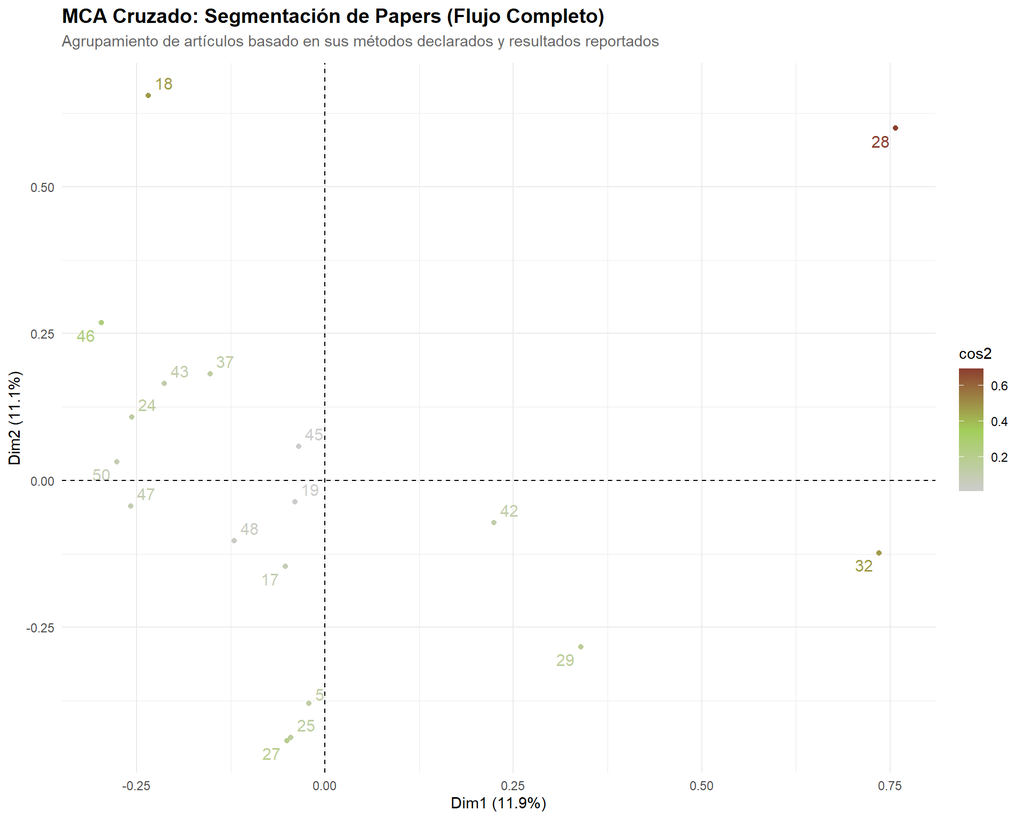

```r
# Generamos el mapa de individuos (Papers) a partir del modelo cruzado
plot_papers_cruzado <- fviz_mca_ind(modelo_mca_cruzado,
                                    repel = TRUE,
                                    col.ind = "cos2", # Colorea por calidad de representación
                                    gradient.cols = c("gray80", "darkolivegreen3", "coral4"),
                                    title = "MCA Cruzado: Segmentación de Papers (Flujo Completo)",
                                    subtitle = "Agrupamiento de artículos basado en sus métodos declarados y resultados reportados") +
  theme_minimal(base_size = 11) +
  theme(
    plot.title = element_text(face = "bold", size = 14),
    plot.subtitle = element_text(color = "gray40", margin = margin(b = 10))
  )

print(plot_papers_cruzado)
```

# Análisis de BRECHAS

Ahora verificamos proporción de papers para comparar si los métodos reportados en métodos necesariamente se intersectan eventualmente con los métodos reportados en resultados.

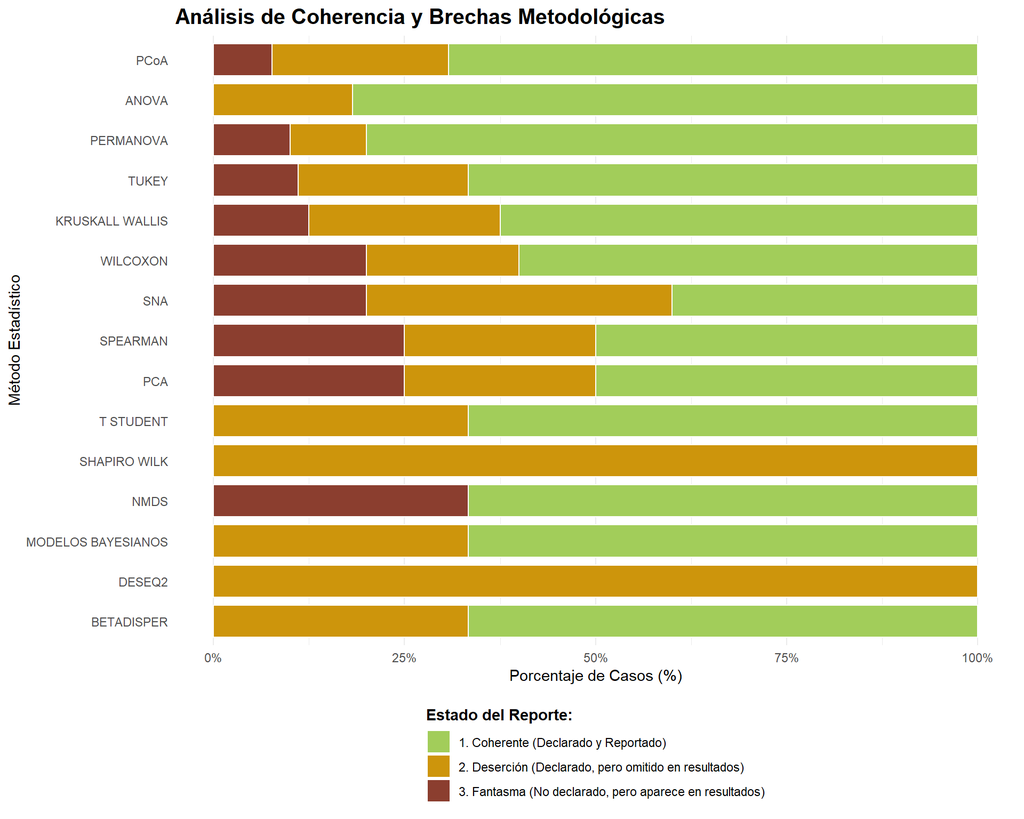

```r
library(dplyr)
library(tidyr)
library(ggplot2)

#  Transformamos las matrices para cruzarlas
df_metodos_largo <- df_num %>%
  mutate(Paper_ID = rownames(.)) %>%
  pivot_longer(cols = -Paper_ID, names_to = "Metodo", values_to = "En_Metodo")

df_res_largo <- df_num_res %>%
  mutate(Paper_ID = rownames(.)) %>%
  pivot_longer(cols = -Paper_ID, names_to = "Metodo", values_to = "En_Resultado")
# Unimos los datos para comparar directamente por Paper y Método
df_brechas <- full_join(df_metodos_largo, df_res_largo, by = c("Paper_ID", "Metodo")) %>%
  replace(is.na(.), 0) # Llenar con 0 si un método existe en una hoja pero no en la otra

# Clasificamos tipo de reporte
df_clasificacion <- df_brechas %>%
  mutate(
    Estado = case_when(
      En_Metodo == 1 & En_Resultado == 1 ~ "1. Coherente (Declarado y Reportado)",
      En_Metodo == 1 & En_Resultado == 0 ~ "2. Deserción (Declarado, pero omitido en resultados)",
      En_Metodo == 0 & En_Resultado == 1 ~ "3. Fantasma (No declarado, pero aparece en resultados)",
      TRUE ~ "No usado"
    )
  ) %>%
  filter(Estado != "No usado")

# Resumimos frecuencias para visualizar
resumen_brechas <- df_clasificacion %>%
  count(Metodo, Estado) %>%
  group_by(Metodo) %>%
  mutate(Total_Apariciones = sum(n)) %>%
  ungroup() %>%
  filter(Total_Apariciones >= 3) # Ocultamos m+etodos usados menos de 3 veces para evitar saturación

# Generamos gráfico de brecha
ggplot(resumen_brechas, aes(x = n, y = reorder(Metodo, Total_Apariciones), fill = Estado)) +
  geom_bar(stat = "identity", position = "fill", color = "white", width = 0.8) +
  scale_fill_manual(values = c("1. Coherente (Declarado y Reportado)" = "darkolivegreen3",
                               "2. Deserción (Declarado, pero omitido en resultados)" = "darkgoldenrod3",
                               "3. Fantasma (No declarado, pero aparece en resultados)" = "coral4")) +
  scale_x_continuous(labels = scales::percent_format()) +
  labs(
    title = "Análisis de Coherencia y Brechas Metodológicas",
    x = "Porcentaje de Casos (%)",
    y = "Método Estadístico",
    fill = "Estado del Reporte:"
  ) +
  theme_minimal(base_size = 11) +
  theme(
    plot.title = element_text(face = "bold", size = 15),
    legend.position = "bottom",
    legend.direction = "vertical",
    legend.title = element_text(face = "bold"),
    panel.grid.major.y = element_blank()
  )
```